# Holiday weather

by Ethan Floate, 07/06/2020

There is nothing I like better than taking a holiday. Thats why, this winter, I'm spending 2 weeks in the southern hemisphere, Cape Town, to be more precise. To maximise vitamin D intake, I will be analysing the weather recorded in Cape Town, during 2014. From this I will plan the date that will (hopefully), provide the best weather for the 2 weeks I spend there.

## Getting the data

Weather Underground keeps historical weather data collected in many airports around the world. Right-click on the following URL and choose 'Open Link in New Window' (or similar, depending on your browser):

http://www.wunderground.com/history

You can copy each month's data directly from the browser to a text editor like Notepad or TextEdit, to obtain a single file with as many months as you wish.

Now load the CSV file into a dataframe making sure that any extra spaces are skipped:

```python
import warnings
warnings.simplefilter('ignore', FutureWarning)

from pandas import *
df = read_csv('CapeTown_CPT_2014.csv', skipinitialspace=True)
```

## Cleaning the data

First we need to clean up the data. I'm not going to make use of `'WindDirDegrees'` in my analysis, but you might in yours so we'll rename `'WindDirDegrees< br />'` to `'WindDirDegrees'`.

```python
df = df.rename(columns={'WindDirDegrees<br />' : 'WindDirDegrees'})
```

remove the `< br />` html line breaks from the values in the `'WindDirDegrees'` column.

```python
df['WindDirDegrees'] = df['WindDirDegrees'].str.rstrip('<br />')
```

and change the values in the `'WindDirDegrees'` column to `float64`:

```python
df['WindDirDegrees'] = df['WindDirDegrees'].astype('float64')
```

```python
df['Date'] = to_datetime(df['Date'])
```

```python
df.index = df['Date']
```

## Finding a summer break

According to meteorologists, summer extends for the whole months of June, July, and August in the northern hemisphere and the whole months of December, January, and February in the southern hemisphere (I will be using just January and February for simplicity's sake). So, as I'm visiting the southern hemisphere, I will create a dataframe that holds just those months using the `datetime` index, like this:

```python
from datetime import datetime
summer = df.loc[datetime(2014,1,1) : datetime(2014,2,28)]
```

I now look for the days with warm temperatures.

```python
summer[summer['Mean TemperatureC'] >= 25]
```

| Date | Date | Max TemperatureC | Mean TemperatureC | Min TemperatureC | Dew PointC | MeanDew PointC | Min DewpointC | Max Humidity | Mean Humidity | Min Humidity | ... | Max VisibilityKm | Mean VisibilityKm | Min VisibilitykM | Max Wind SpeedKm/h | Mean Wind SpeedKm/h | Max Gust SpeedKm/h | Precipitationmm | CloudCover | Events | WindDirDegrees |
| --- | --- | --- | --- | --- | --- | --- | --- | --- | --- | --- | --- | --- | --- | --- | --- | --- | --- | --- | --- | --- | --- |
| 2014-01-21 | 2014-01-21 | 31 | 25 | 19 | 18 | 16 | 14 | 78 | 58 | 31 | ... | 10.0 | 10.0 | 10.0 | 35 | 24 | 45.0 | 0.0 | 1.0 | NaN | 207.0 |
| 2014-01-30 | 2014-01-30 | 31 | 26 | 21 | 19 | 17 | 15 | 73 | 59 | 40 | ... | 31.0 | 13.0 | 10.0 | 37 | 27 | NaN | 0.0 | 1.0 | NaN | 169.0 |
| 2014-01-31 | 2014-01-31 | 35 | 28 | 20 | 20 | 18 | 15 | 73 | 56 | 28 | ... | 10.0 | 10.0 | 10.0 | 24 | 13 | NaN | 0.0 | 1.0 | NaN | 205.0 |
| 2014-02-14 | 2014-02-14 | 33 | 26 | 19 | 20 | 18 | 15 | 83 | 60 | 36 | ... | 31.0 | 14.0 | 10.0 | 35 | 21 | NaN | 0.0 | 1.0 | NaN | 172.0 |
| 2014-02-15 | 2014-02-15 | 33 | 28 | 22 | 21 | 19 | 18 | 78 | 64 | 36 | ... | 26.0 | 16.0 | 10.0 | 34 | 16 | NaN | 0.0 | 1.0 | NaN | 195.0 |
| 2014-02-16 | 2014-02-16 | 36 | 28 | 20 | 21 | 19 | 17 | 83 | 61 | 38 | ... | 31.0 | 22.0 | 10.0 | 29 | 18 | NaN | 0.0 | 1.0 | NaN | 202.0 |
| 2014-02-17 | 2014-02-17 | 29 | 26 | 22 | 21 | 19 | 16 | 88 | 69 | 39 | ... | 31.0 | 14.0 | 9.0 | 34 | 13 | NaN | 0.0 | 4.0 | NaN | 205.0 |
| 2014-02-18 | 2014-02-18 | 31 | 27 | 22 | 21 | 20 | 18 | 94 | 68 | 43 | ... | 31.0 | 12.0 | 10.0 | 42 | 31 | NaN | 0.0 | 1.0 | NaN | 174.0 |
| 2014-02-25 | 2014-02-25 | 33 | 26 | 19 | 17 | 16 | 14 | 73 | 55 | 30 | ... | 31.0 | 14.0 | 10.0 | 40 | 26 | NaN | 0.0 | 1.0 | NaN | 158.0 |
| 2014-02-26 | 2014-02-26 | 34 | 27 | 20 | 17 | 16 | 14 | 69 | 54 | 26 | ... | 31.0 | 16.0 | 10.0 | 24 | 14 | NaN | 0.0 | 1.0 | NaN | 203.0 |

10 rows × 23 columns

The table above show's the 10 days that had a mean temperature of 25 or above, from Jan-Feb of 2014 in Cape Town. Although it is hard to draw conclusions from the data when it is just presented in a table format. Let's try plotting our data in other ways:

```python
%matplotlib inline
#df['Mean TemperatureC'].plot(grid=True, figsize=(10,5))
```

Now let's plot the `'Min TemperatureC'`, `'Mean TemperatureC'` and `'Max TemperatureC'` for the summer:

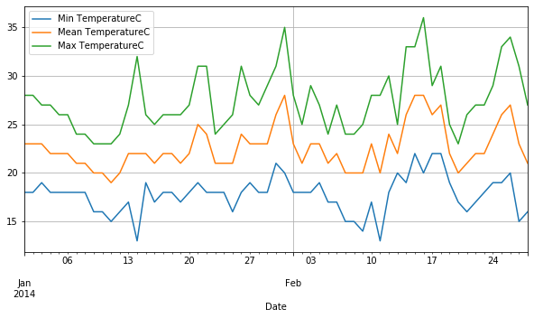

```python
summer[['Min TemperatureC', 'Mean TemperatureC', 'Max TemperatureC']].plot(grid=True, figsize=(10,5))
```

The two months seem tightly contested when it comes to temperature. I would like to avoid rain this holiday, and to avoid particularly high levels of humidity. So, let's try factoring in the variables `'Precipitationmm'` and `'Mean Humidity'` into our graph:

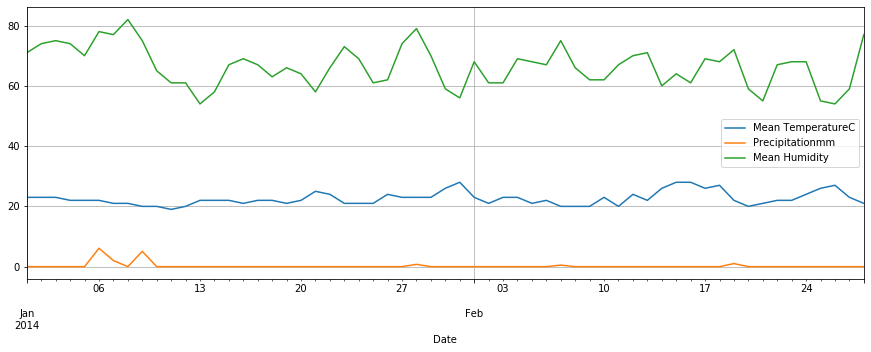

```python
summer[['Mean TemperatureC', 'Precipitationmm', 'Mean Humidity']].plot(grid=True, figsize=(15,5))
```

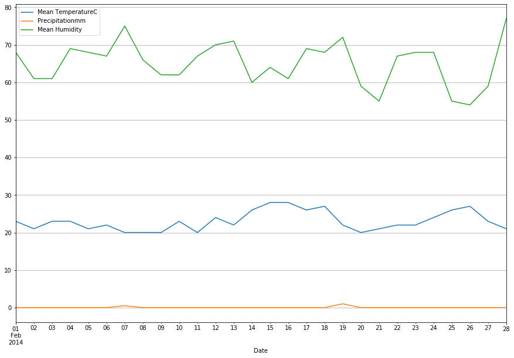

```python
feb = summer.loc[datetime(2014,2,1) : datetime(2014,2,28)]
feb[['Mean TemperatureC', 'Precipitationmm', 'Mean Humidity']].plot(grid=True, figsize=(15,10))
```